# Network Analysis

Akhila Saineni, Nihar Garlapati

7/12/2020

```r
library(igraph)
library(ggplot2)
library(expss)
library(ggrepel)

net1<-read.graph("/Users/akhilasaineni/Downloads/HU/2020Summer/DataViz512/7_0618V/cnet.dms",
                 format="GraphML")

htmlTable(
  fre(
 vertex.attributes(net1)$party) %>%
   set_caption("House of Representatives")
   )
```

| House of Representatives vertex.attributes(net1)$party | House of Representatives Count | House of Representatives Valid percent | House of Representatives Percent | House of Representatives Responses, % | House of Representatives Cumulative responses, % |
| --- | --- | --- | --- | --- | --- |
| Democratic | 236 | 54.6 | 54.6 | 54.6 | 54.6 |
| Republican | 196 | 45.4 | 45.4 | 45.4 | 100.0 |
| #Total | 432 | 100 | 100 | 100 |  |
| <NA> | 0 |  | 0.0 |  |  |

## Introduction

The main objective of the following analysis is to analyze the house members and their cosponsored bills. Calculating network metrics such as closeness,betweenness etc. Also looking at various cliques and communities within the network

## Loading Data

We loaded the “cnet” data that includes various vertex attributes along with the corresponding edge attributes. The network loaded is a very large network and in the below analysis, We would sparsify the data into various sub networks.

## Results

### Basic network and the breakdown within parties

We can look at the basic network and as mentioned, it is a very large network with 236 Democrats and 196 Republicans who have cosponsored many bills together. The size of the node/Vertex is determined by its degree. In general democrats(Avg:49.4) have higher degree than the republicans(Avg: 33.01)

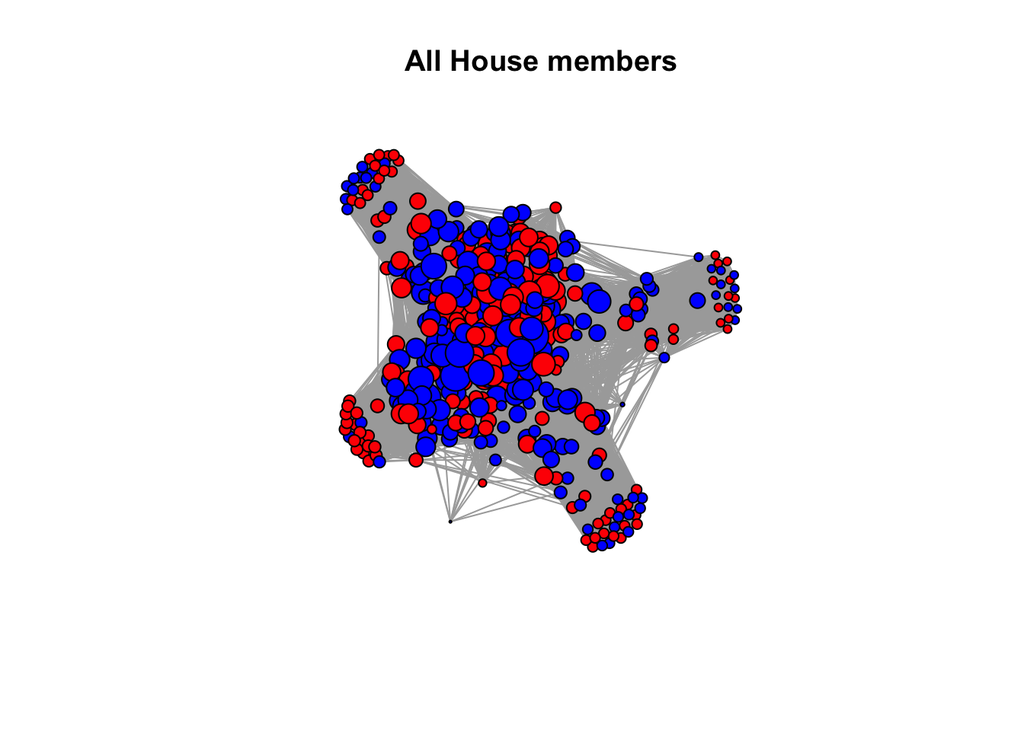

```r
V(net1)$colorz = ifelse(V(net1)$party == "Republican", "red", "blue")
democrats <- net1- V(net1)[which(V(net1)$party=='Republican')]
republicans <- net1- V(net1)[which(V(net1)$party=='Democratic')]


#Democrats and republicans with high degree of closeness.


par(mfrow=c(1,1))

set.seed(100)
plot(net1,
     vertex.color=V(net1)$colorz ,
     vertex.size=degree(net1)*0.10,
     layout =  layout.fruchterman.reingold,
     vertex.label=NA,
     vertex.label.dist=5,
     edge.arrow.size=.3,
     vertex.label.degree = pi/2,
     vertex.label.cex=.9,
)
title("All House members")
```

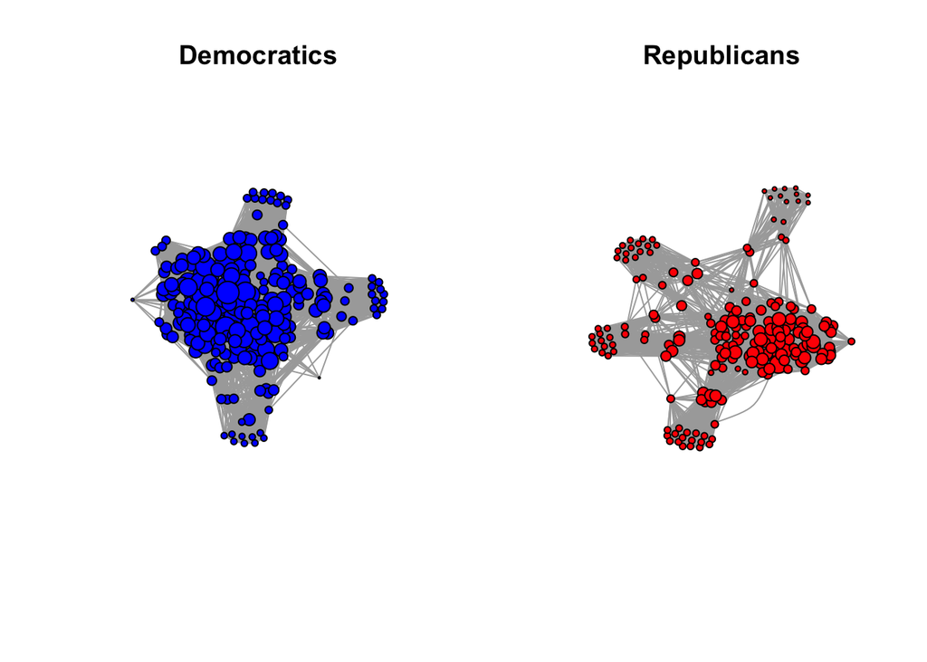

```r
par(mfrow=c(1,2))

set.seed(100)
plot(democrats,
     vertex.color="blue",
     vertex.size=degree(democrats)*0.20,
     layout =  layout.fruchterman.reingold,
     vertex.label=NA,
     vertex.label.dist=5,
     edge.arrow.size=.3,
     vertex.label.degree = pi/2,
     vertex.label.cex=.9,
     )
   title("Democratics")
set.seed(100)
plot(republicans,
     vertex.color="Red",
     vertex.size=degree(republicans)*0.20,
     layout =  layout.fruchterman.reingold,
     vertex.label=NA,
     vertex.label.dist=5,
     edge.arrow.size=.4,
     vertex.label.degree = -pi/2,
     vertex.label.cex=.9
   )
title("Republicans")
```

### Sub Network of house members with more than average number of cosponsored bills

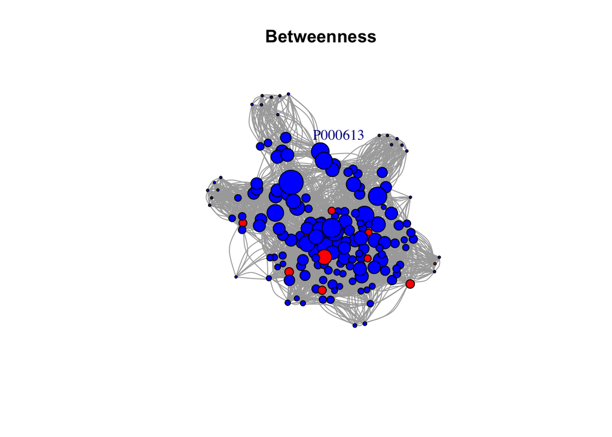

```r
net1_clean<-net1- V(net1)[which(V(net1)$cosponsored==-2147483648)]

higherbills <- net1_clean- V(net1_clean)[which(V(net1_clean)$cosponsored<mean(V(net1_clean)$cosponsored))]


#Statistics

ec<- eigen_centrality(higherbills, directed = FALSE)
ecv<-ec$vector

par(mfrow=c(1,1))

set.seed(100)
plot(higherbills
     ,vertex.color=V(higherbills)$colorz
     ,vertex.size=sqrt(betweenness(higherbills))
     ,vertex.label=ifelse(betweenness(higherbills)==max(betweenness(higherbills)),V(higherbills)$name,NA)
     ,edge.curved=T,
     layout =  layout.fruchterman.reingold,
     vertex.label.dist = 8
)
title("Betweenness ")
```

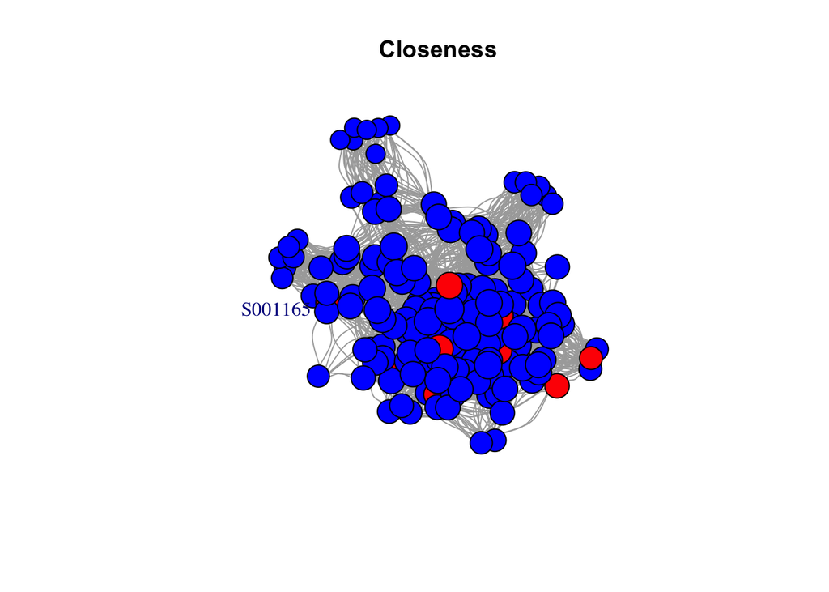

```r
set.seed(100)
plot(higherbills
     ,vertex.color=V(higherbills)$colorz
     ,vertex.size=closeness(higherbills)*5000
     ,edge.curved=T,
     layout =  layout.fruchterman.reingold
     ,vertex.label=ifelse(closeness(higherbills)==
                            max(closeness(higherbills)),V(higherbills)$name,NA)
     ,vertex.label.dist = 15,
     vertex.label.degree = pi

    )

    title("Closeness")
```

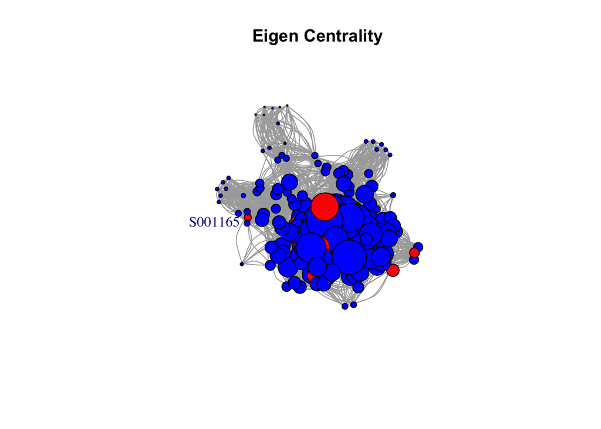

```r
set.seed(100)
plot(higherbills
     ,vertex.color=V(higherbills)$colorz
     ,vertex.size=ecv*50
     ,edge.curved=T,
     layout =  layout.fruchterman.reingold
     ,vertex.label=ifelse(closeness(higherbills)==
                            max(closeness(higherbills)),V(higherbills)$name,NA)
     ,vertex.label.dist = 15,
     vertex.label.degree = pi

    )

    title("Eigen Centrality")
```

### Largest Cliques

In the below analysis, We have created 2 new sub networks that consists of top 100 house members based on their seniority rank and also the bottom 100 house members based on their seniority rank.

As you can see, In the top 100 subnetwork, We were able to identify a clique with majority as democrats and minority as republicans, In the bottom 100 subnetwork, We were able to identify another clique with majority as republicans and minority as democrats.

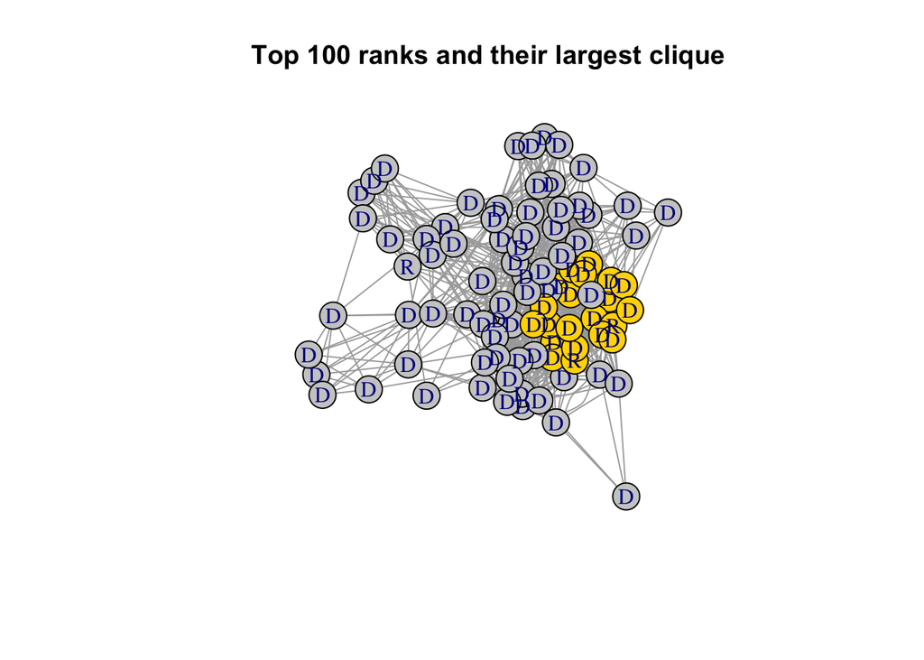

```r
#Top and bottom 100 representatives, their cliques and communities
top100<-net1_clean- V(net1_clean)[which(V(net1_clean)$rank_from_high>100)]


par(mfrow=c(1,1))

vcol <- rep("grey80", vcount(top100))
vcol[unlist(largest_cliques(top100))] <- "gold"

plot(as.undirected(top100),vertex.size=15, vertex.label=ifelse(V(top100)$party=="Democratic","D","R"), vertex.color=vcol)
title("Top 100 ranks and their largest clique")
```

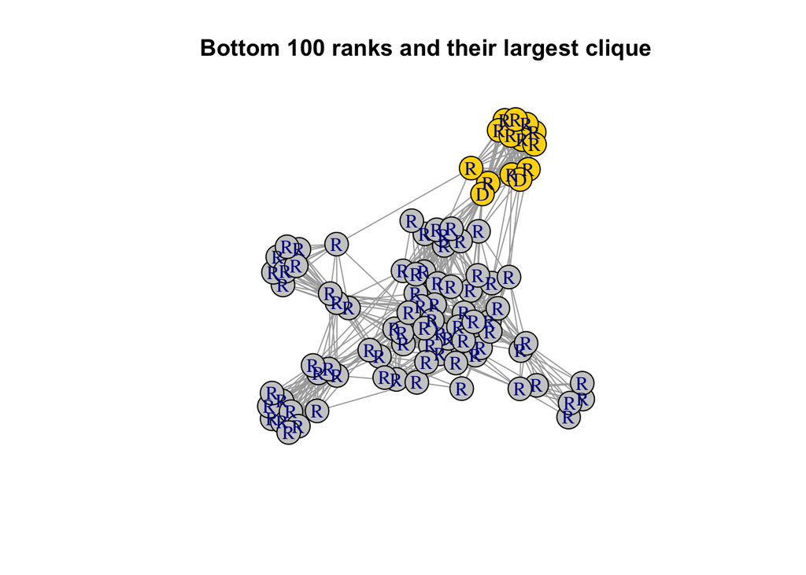

```r
bottom100<-net1_clean- V(net1_clean)[which(V(net1_clean)$rank_from_high<337)]


vcol <- rep("grey80", vcount(bottom100))
vcol[unlist(largest_cliques(bottom100))] <- "gold"
plot(as.undirected(bottom100),vertex.size=15, vertex.label=ifelse(V(bottom100)$party=="Democratic","D","R"), vertex.color=vcol)
title("Bottom 100 ranks and their largest clique")
```

### Community detection based on edge betweenness (Newman-Girvan)

In the below analysis we have used Newman-Girvan algorithm to partition the top and bottom 100 sub networks to various communities. The top 100 sub network has 28 communities, which tells us that there aren’t any big communities in this sub network, However in the bottom 100 sub network, we have only 8 communities, Which are bigger communities largely consisting of republicans.

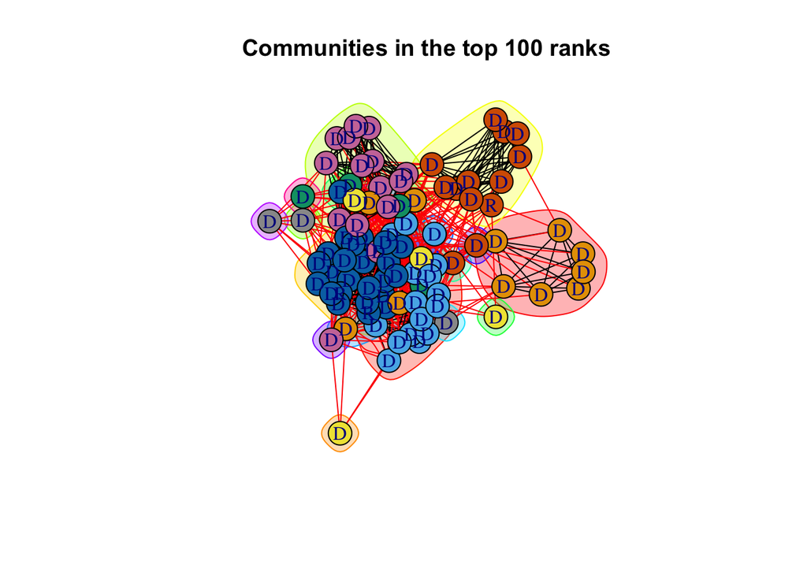

```r
set.seed(100)
ceb <- cluster_edge_betweenness(top100)
plot(ceb, top100, vertex.label=ifelse(V(top100)$party=="Democratic","D","R"))
title("Communities in the top 100 ranks")
```

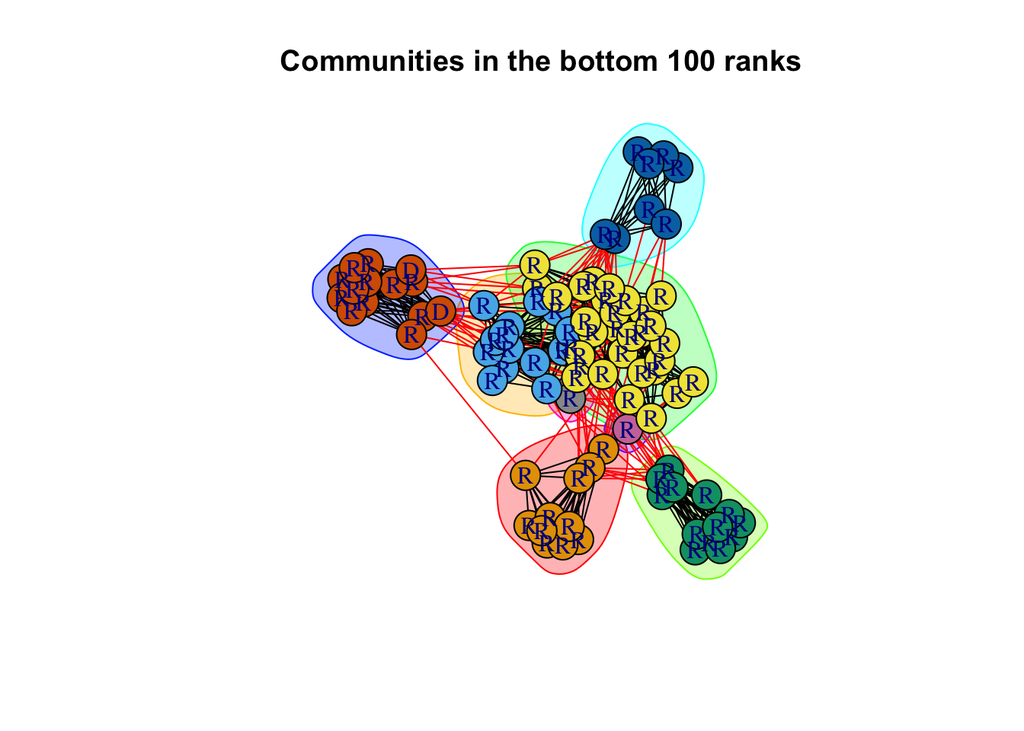

```r
#length(ceb)
#membership(ceb)
#length(ceb2)

set.seed(100)
ceb2 <- cluster_edge_betweenness(bottom100)
plot(ceb2, bottom100, vertex.label=ifelse(V(bottom100)$party=="Democratic","D","R"))
title("Communities in the bottom 100 ranks")
```

### Diameter of the top 10 ranks

In the analysis, We are looking into the top 10 house members by seniority. The goal is to calculate the longest Geodesic distance within the top 10 ranks. It appears that F000466(R) and G000551(D) has the longest distance between them. The path/edges between them is colored in orange. The primary affiliations of F000466 & G000551 are Foreign affairs and Natural Resources respectively.

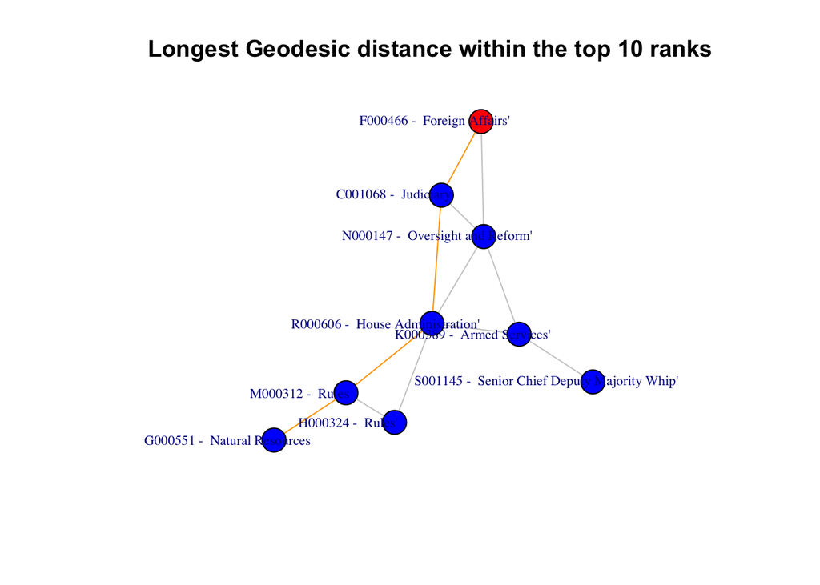

```r
#Diameter

top10<-net1_clean- V(net1_clean)[which(V(net1_clean)$rank_from_high>10)]

diameter<-get_diameter(top10, directed = F)

ecol <- rep("gray80", ecount(top10))

ecol[E(top10, path=diameter)] <- "orange"

set.seed(102)
plot(top10, vertex.color=V(top10)$colorz, edge.color=ecol, edge.arrow.mode=0, vertex.label=paste(V(top10)$name,"- ",V(top10)$a)
     ,vertex.label.dist = 4,
     vertex.label.degree = -pi
     ,vertex.label.cex=.7)
title("Longest Geodesic distance within the top 10 ranks ")
```

```r
#cats<-V(top10)$a
#d<-V(top10)$name
#catsd<-as.data.frame(cats,d)
#catsd
```

### Graphs

```r
library(igraph)
library(ggrepel)
library(ggplot2)


closeness<-closeness(net1_clean)
cosponsored<-V(net1_clean)$cosponsored
betweenness<-betweenness(net1_clean)
party<-V(net1_clean)$party
name<-V(net1_clean)$name

abp<-as.data.frame(cbind(closeness,cosponsored,betweenness,party,name))

summary(abp)
```

```
##                closeness    cosponsored            betweenness
##  0.00111731843575419: 25   91     :  5   0               : 90
##  0.00108342361863489: 20   107    :  4   100.540430293519:  7
##  0.00115606936416185: 20   118    :  4   71.3896832180429:  6
##  0.00119617224880383: 20   120    :  4   253.200571788134:  5
##  0.00137551581843191: 15   122    :  4   100.871006926699:  4
##  0.00133155792276964: 14   189    :  4   116.670163312395:  4
##  (Other)            :291   (Other):380   (Other)         :289
##         party          name
##  Democratic:213   A000055:  1
##  Republican:192   A000369:  1
##                   A000370:  1
##                   A000371:  1
##                   A000372:  1
##                   A000374:  1
##                   (Other):399
```

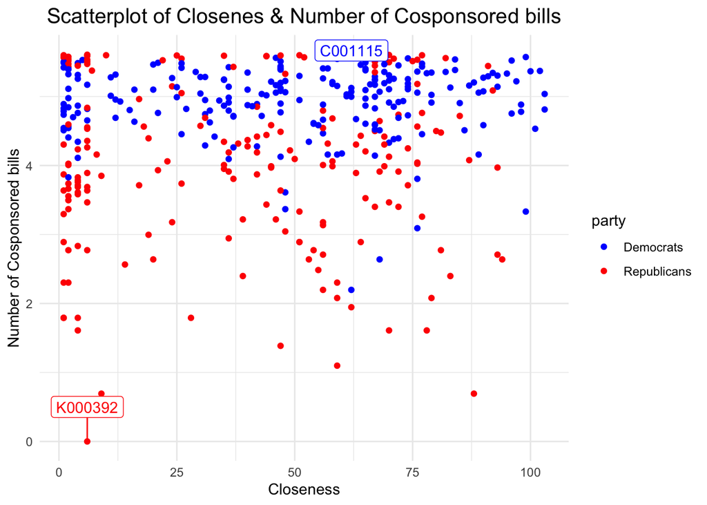

```r
abp$closeness=as.numeric(abp$closeness)

abp$betweenness=as.numeric(abp$betweenness)

abp$cosponsored=as.numeric(abp$cosponsored)


#Scatterplot

abp$label=ifelse(abp$cosponsored==max(abp$cosponsored),paste(abp$name),NA)
abp$label_low=ifelse(abp$cosponsored==min(abp$cosponsored),paste(abp$name),NA)

ggplot(abp, aes(closeness,log(cosponsored), color=party)) +
  geom_point() +
  geom_label_repel(label=abp$label,color="blue",force=100,nudge_x = 5,
                   nudge_y = 100000, na.rm = TRUE)+
  geom_label_repel(label=abp$label_low,color="red",force=100,nudge_x = 0,
                   nudge_y = 0.5, na.rm = TRUE) +
  scale_color_manual(values = c("blue", "red"),
                       labels = c("Democrats", "Republicans")) +
  theme_minimal() +
ggtitle("Scatterplot of Closenes & Number of Cosponsored bills") +
  theme(plot.title = element_text(size = 15,hjust = 0.5),plot.subtitle = element_text(size = 8) )  +
  xlab("Closeness") +
  ylab("Number of Cosponsored bills")
```

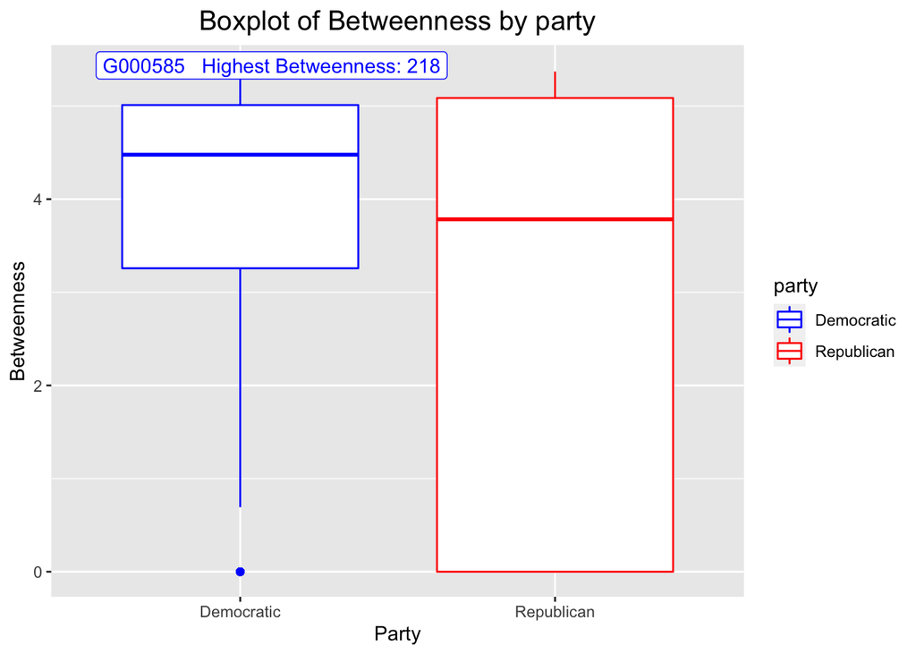

```r
#boxplot

abp$label_b_o=ifelse(abp$betweenness==max(abp$betweenness) ,paste(abp$name,"  Highest Betweenness:", round(abp$betweenness,2)),NA)

ggplot(abp, aes(party,log(betweenness), color=party)) +
  geom_boxplot() +
  scale_color_manual(values=c("blue", "red"))+
  geom_label_repel(label=abp$label_b_o,color="blue",force=100,nudge_x = 0.1, nudge_y = 0.8, na.rm = TRUE) +
  ggtitle("Boxplot of Betweenness by party") +
  theme(plot.title = element_text(size = 15,hjust = 0.5),plot.subtitle = element_text(size = 8) ) +
  xlab("Party") +
  ylab("Betweenness")
```

## Bibliography

Ognyanova, k(2016) Network Analysis and Visualization with R and igraph www.kateto.net

https://igraph.org/r/doc/ (2019)

Fortunato, S(2016) Community detection in networks

2019 Report card https://www.govtrack.us/congress/members/report-cards/2019/house/cosponsored